# Sprawozdanie z Projektu - Ekonometria

Jakub Anczyk

2023-05-06

## Przewidywanie cen nieruchomości w Miami

Zestaw danych wykorzystany do projektu pochodzi z Kaggle i zawiera podstawowe parametry 13 932 domów jednorodzinnych sprzedanych w Miami w 2016 roku: https://www.kaggle.com/datasets/deepcontractor/miami-housing-dataset.

Celem projektu jest zbudowanie modelu pozwalającego przewidzieć cenę rynkową nieruchomości na podstawie jej parametrów.

### Budowa modelu

W pierwszym kroku wybieram wszystkie dane z podanego zestawu danych i tworzę zestaw danych wyłącznie numerycznych. Kod nie zawiera kolejnych kroków czyszczenia i dostosowywania danych, ponieważ dane są już gotowe do analizy.

Poniżej znajduje się krótkie podsumowanie dostępnych zmiennych:

```r
data <- read.csv("miami-housing.csv")

data_num <- data %>%
  select_if(~all(!is.character(.)))

stargazer(data_num, type="text")
```

```
##
## ======================================================================================================
## Statistic           N            Mean                St. Dev.              Min              Max
## ------------------------------------------------------------------------------------------------------
## LATITUDE          13,932        25.729                 0.141             25.434           25.974
## LONGITUDE         13,932        -80.327                0.089             -80.542          -80.120
## PARCELNO          13,932 2,356,495,918,249.000 1,199,290,453,568.000 102,000,801,020 3,660,170,162,200
## SALE_PRC          13,932      399,941.900           317,214.700          72,000          2,650,000
## LND_SQFOOT        13,932       8,620.880             6,070.089            1,248           57,064
## TOT_LVG_AREA      13,932       2,058.045              813.539              854             6,287
## SPEC_FEAT_VAL     13,932       9,562.493            13,890.970              0             175,020
## RAIL_DIST         13,932       8,348.549             6,178.027           10.500         29,621.500
## OCEAN_DIST        13,932      31,690.990            17,595.080           236.100        75,744.900
## WATER_DIST        13,932      11,960.280            11,932.990            0.000         50,399.800
## CNTR_DIST         13,932      68,490.330            32,008.470          3,825.600       159,976.500
## SUBCNTR_DI        13,932      41,115.050            22,161.830          1,462.800       110,553.800
## HWY_DIST          13,932       7,723.771             6,068.936           90.200         48,167.300
## age               13,932        30.669                21.153                0               96
## avno60plus        13,932         0.015                 0.121                0                1
## month_sold        13,932         6.656                 3.302                1               12
## structure_quality 13,932         3.514                 1.097                1                5
## ------------------------------------------------------------------------------------------------------
```

Następnie zaczynam budowę modelu ekonometrycznego od zbudowania macierzy korelacji, macierzy R0 oraz R:

```r
cor_matrix <- cor(data_num)
R_0 <- cor_matrix[4,-4]
R <- cor_matrix[-4,-4]
```

W kolejnym kroku buduję macierz zawierającą zestawienie wszystkich możliwych kombinacji zestawień zmiennych.

```r
comb <- expand.grid(rep(list(c(T,F)), 16))
tot_comb <- nrow(comb)-1
comb_capacity <- comb %>% mutate(capacity = 0)
```

Następnie obliczam całkowitą pojemność informacji każdej uzyskanej w ten sposób kombinacji.

```r
for(row in 1:tot_comb)
{

  k <-c(1:16)[unlist(comb[row,])]
  H <- 0

  for(i in k)
  {
    H <- H + (R_0[i]^2)/sum(abs(R[k,i]))
  }

  comb_capacity[row, 17] = H
}
```

Finalnie sortuję uzyskane w ten sposób dane i wybieram kombinację o największej możliwej pojemności informacyjnej.

```r
comb_capacity <- comb_capacity %>% arrange(desc(capacity))
max_capacity <- comb_capacity[1,]
x <-c(1:16)[unlist(comb_capacity[1,1:16])]
y <- names(R_0[x])
y[6] <- "SALE_PRC"
```

Teraz mozemy podsumować uzyskany w ten sposób model.

```r
final_model <- lm(SALE_PRC ~ .,data[y])
summary(final_model)
```

```
##
## Call:
## lm(formula = SALE_PRC ~ ., data = data[y])
##
## Residuals:
##     Min      1Q  Median      3Q     Max
## -812900 -100480  -13799   70314 1965847
##
## Coefficients:
##                     Estimate Std. Error t value Pr(>|t|)
## (Intercept)       -1.098e+05  7.659e+03  -14.33   <2e-16 ***
## TOT_LVG_AREA       2.065e+02  2.287e+00   90.32   <2e-16 ***
## SPEC_FEAT_VAL      3.221e+00  1.346e-01   23.94   <2e-16 ***
## OCEAN_DIST        -4.152e+00  1.075e-01  -38.63   <2e-16 ***
## SUBCNTR_DI        -2.269e+00  8.632e-02  -26.29   <2e-16 ***
## structure_quality  7.933e+04  1.637e+03   48.45   <2e-16 ***
## ---
## Signif. codes:  0 '***' 0.001 '**' 0.01 '*' 0.05 '.' 0.1 ' ' 1
##
## Residual standard error: 187400 on 13926 degrees of freedom
## Multiple R-squared:  0.6509, Adjusted R-squared:  0.6508
## F-statistic:  5194 on 5 and 13926 DF,  p-value: < 2.2e-16
```

**TOT_LVG_AREA** (total living area) - to wartość odpowiadająca całkowitej powierzchni użytkowej lokalu w stopach kwadratowych.

**SPEC_FEAT_VAL** (total value of special features) - podana w dolarach wartość wszystkich dodatkowych cech lokalu, takich jak baseny, jaccuzi, szklarnie przydomowe etc.,

### Diagnostyka

Jak widać na następujących wykresach, zmienne pokazują różne aspekty zmiany ceny, to jest zachowują się różnie zestawione z ceną nieruchomości. Gdyby wykresy były do siebie podobne, oznaczałoby to dużą autokorelację.

Wizualna analiza wykresów pozwala przypuścić, że autokorelacja między zmiennymi jest niewielka.

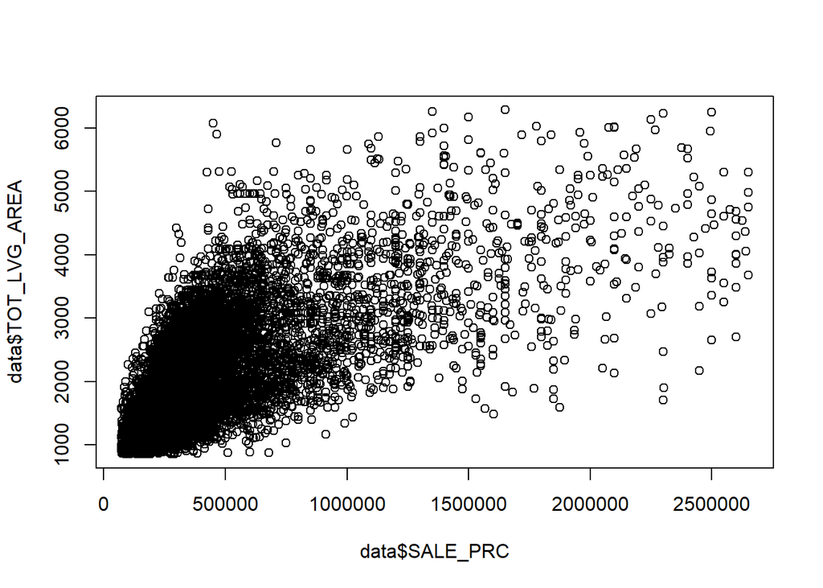

```r
plot(data$SALE_PRC, data$TOT_LVG_AREA)
```

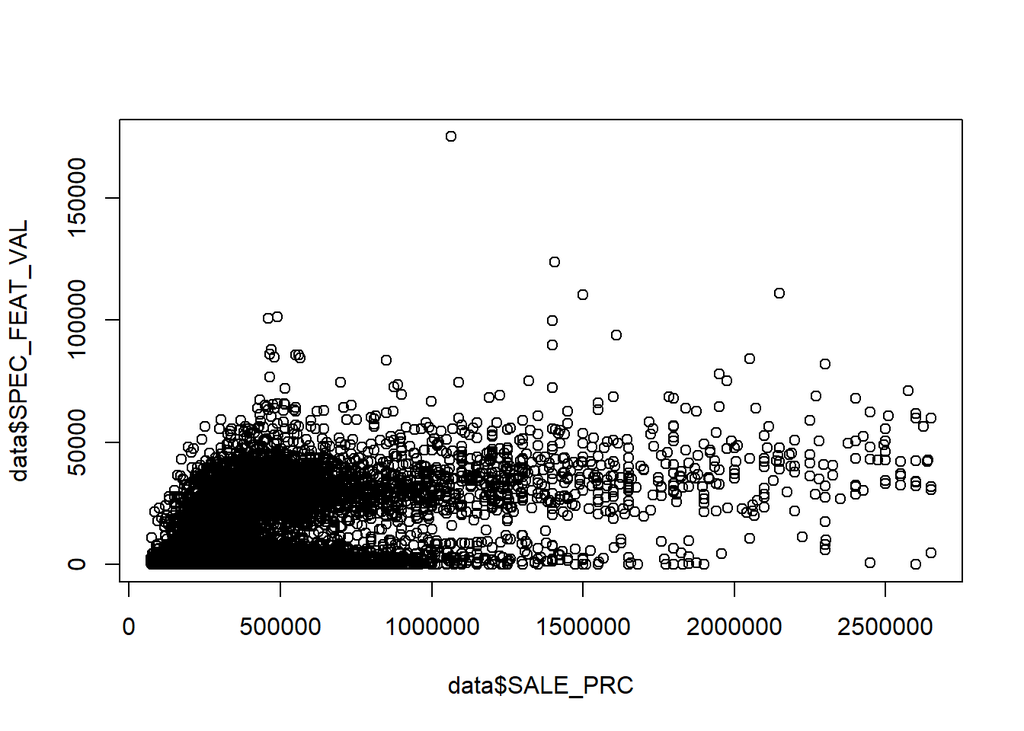

```r
plot(data$SALE_PRC, data$SPEC_FEAT_VAL)
```

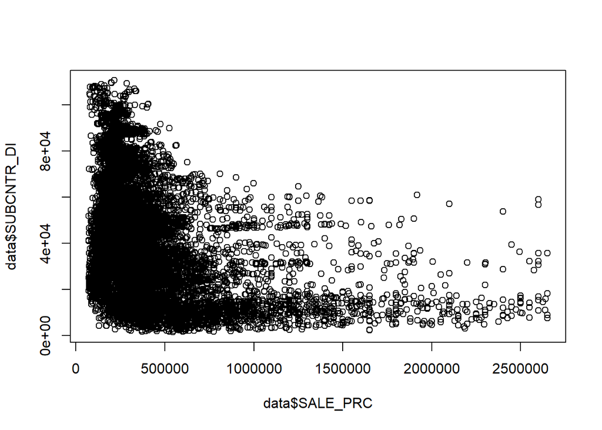

```r
plot(data$SALE_PRC, data$SUBCNTR_DI)
```

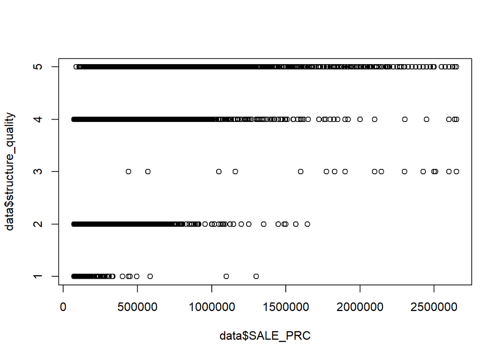

```r
plot(data$SALE_PRC, data$structure_quality)
```

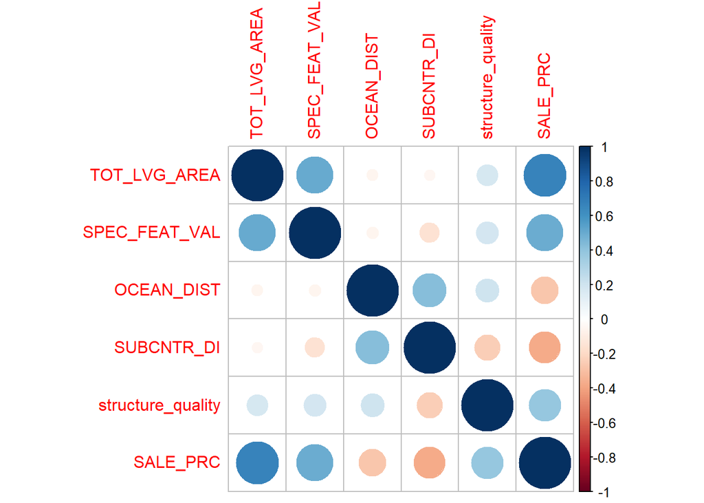

```r
R <- cor(data_num[,y])
corrplot(R)
```

```r
dwtest(final_model)
```

```
##
##  Durbin-Watson test
##
## data:  final_model
## DW = 0.92309, p-value < 2.2e-16
## alternative hypothesis: true autocorrelation is greater than 0
```

#### Test normalności reszt

Test normalności reszt pokazuje, że statystyka R-kwadrat jest niewystarczająca, aby pozytywnie ocenić model.

```r
summary(final_model)
```

```
##
## Call:
## lm(formula = SALE_PRC ~ ., data = data[y])
##
## Residuals:
##     Min      1Q  Median      3Q     Max
## -812900 -100480  -13799   70314 1965847
##
## Coefficients:
##                     Estimate Std. Error t value Pr(>|t|)
## (Intercept)       -1.098e+05  7.659e+03  -14.33   <2e-16 ***
## TOT_LVG_AREA       2.065e+02  2.287e+00   90.32   <2e-16 ***
## SPEC_FEAT_VAL      3.221e+00  1.346e-01   23.94   <2e-16 ***
## OCEAN_DIST        -4.152e+00  1.075e-01  -38.63   <2e-16 ***
## SUBCNTR_DI        -2.269e+00  8.632e-02  -26.29   <2e-16 ***
## structure_quality  7.933e+04  1.637e+03   48.45   <2e-16 ***
## ---
## Signif. codes:  0 '***' 0.001 '**' 0.01 '*' 0.05 '.' 0.1 ' ' 1
##
## Residual standard error: 187400 on 13926 degrees of freedom
## Multiple R-squared:  0.6509, Adjusted R-squared:  0.6508
## F-statistic:  5194 on 5 and 13926 DF,  p-value: < 2.2e-16
```

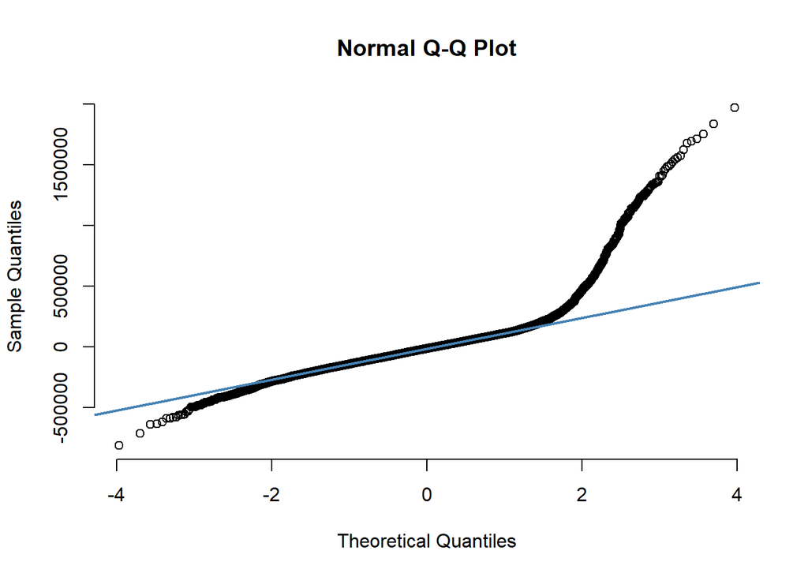

```r
qqnorm(final_model$residuals, pch = 1, frame = FALSE)
qqline(final_model$residuals, col = "steelblue", lwd = 2)
```

Aby poprawić model, próbuję najpierw przekształcić go za pomocą logarytmu.

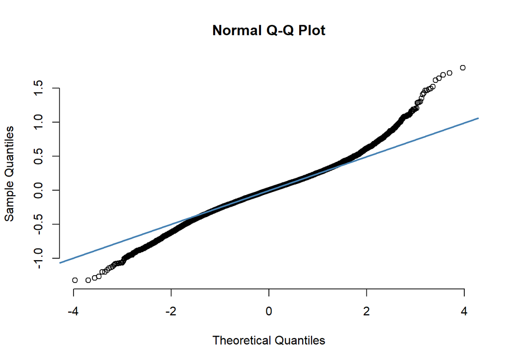

```r
final_model <- lm(log(SALE_PRC) ~ ., data = data[y])
qqnorm(final_model$residuals, pch = 1, frame = FALSE)
qqline(final_model$residuals, col = "steelblue", lwd = 2)
```

```r
summary(final_model)
```

```
##
## Call:
## lm(formula = log(SALE_PRC) ~ ., data = data[y])
##
## Residuals:
##      Min       1Q   Median       3Q      Max
## -1.32234 -0.16964  0.00265  0.16511  1.80053
##
## Coefficients:
##                     Estimate Std. Error t value Pr(>|t|)
## (Intercept)        1.163e+01  1.187e-02  979.87   <2e-16 ***
## TOT_LVG_AREA       4.091e-04  3.544e-06  115.45   <2e-16 ***
## SPEC_FEAT_VAL      4.417e-06  2.086e-07   21.18   <2e-16 ***
## OCEAN_DIST        -4.712e-06  1.666e-07  -28.28   <2e-16 ***
## SUBCNTR_DI        -5.636e-06  1.338e-07  -42.12   <2e-16 ***
## structure_quality  1.638e-01  2.537e-03   64.54   <2e-16 ***
## ---
## Signif. codes:  0 '***' 0.001 '**' 0.01 '*' 0.05 '.' 0.1 ' ' 1
##
## Residual standard error: 0.2905 on 13926 degrees of freedom
## Multiple R-squared:  0.7383, Adjusted R-squared:  0.7382
## F-statistic:  7857 on 5 and 13926 DF,  p-value: < 2.2e-16
```

Jest to rzeczywiście wystarczające aby uzyskać wartość R-kwadrat powyżej 70%, jednak podniesienie ceny jeszcze to czwartej potęgi pomoże uzyskać R-kwadrat bliższe 75%. Wciąż jednak nawet takie przekształcenie nie jest wystarczające by pozbyć się tzw. “grubych ogonów”.

Taki rozkład oznacza dużo wyższe niż w rozkładzie normalnym prawdopodobieństwo wystąpienia skrajnie wysokich (gruby prawy ogon) lub niskich (gruby lewy ogon) wartości.

Wynik testu Shapiro-Wilka pokazuje, że są podstawy do odrzucenia hipotezy zerowej o normalności reszt, tj. wartości resztowe nie mają rozkładu normalnego.

```r
final_model <- lm(log10(SALE_PRC)^4 ~ .,data = data[y])
summary(final_model)
```

```
##
## Call:
## lm(formula = log10(SALE_PRC)^4 ~ ., data = data[y])
##
## Residuals:
##     Min      1Q  Median      3Q     Max
## -426.76  -55.41   -3.01   47.97  635.75
##
## Coefficients:
##                     Estimate Std. Error t value Pr(>|t|)
## (Intercept)        6.135e+02  3.642e+00  168.46   <2e-16 ***
## TOT_LVG_AREA       1.267e-01  1.087e-03  116.53   <2e-16 ***
## SPEC_FEAT_VAL      1.517e-03  6.398e-05   23.72   <2e-16 ***
## OCEAN_DIST        -1.696e-03  5.111e-05  -33.19   <2e-16 ***
## SUBCNTR_DI        -1.703e-03  4.104e-05  -41.48   <2e-16 ***
## structure_quality  4.982e+01  7.784e-01   64.00   <2e-16 ***
## ---
## Signif. codes:  0 '***' 0.001 '**' 0.01 '*' 0.05 '.' 0.1 ' ' 1
##
## Residual standard error: 89.12 on 13926 degrees of freedom
## Multiple R-squared:  0.7452, Adjusted R-squared:  0.7452
## F-statistic:  8148 on 5 and 13926 DF,  p-value: < 2.2e-16
```

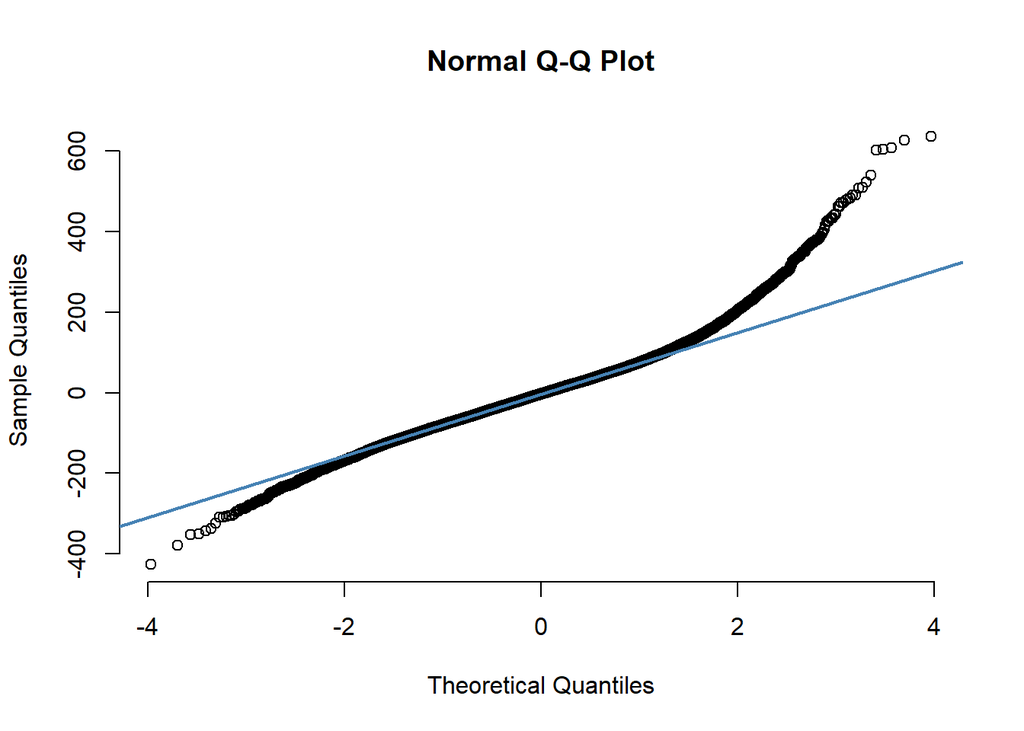

```r
qqnorm(final_model$residuals, pch = 1, frame = FALSE)
qqline(final_model$residuals, col = "steelblue", lwd = 2)
```

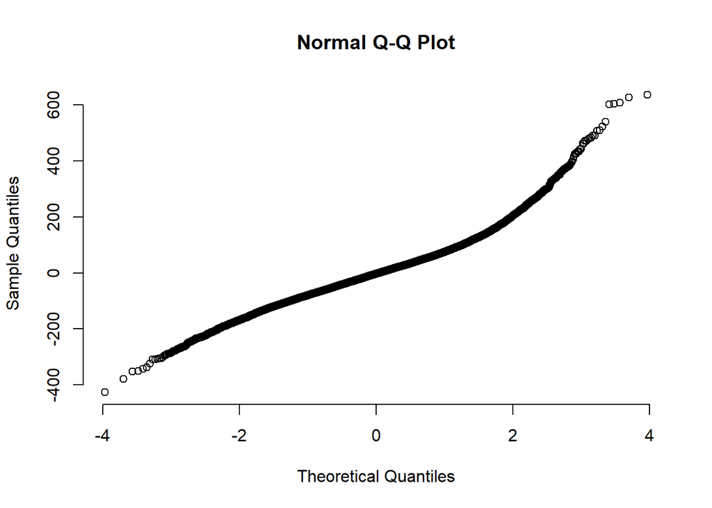

```r
qqnorm(final_model$residuals, pch = 1, frame = FALSE)
```

```r
shapiro.test(sample(final_model$residuals, 5000, replace = FALSE, prob = NULL))
```

```
##
##  Shapiro-Wilk normality test
##
## data:  sample(final_model$residuals, 5000, replace = FALSE, prob = NULL)
## W = 0.96671, p-value < 2.2e-16
```

```r
# niestety p-value bardzo male, poniżej 0.05
```

#### Wykres i histogram wartości teoretycznych i reszt

Jak widać na wykresie wartości teoretycznych i reszt, obserwacje koncentrują się wyraźnie wokół zera, choć wykres jest zdecydowanie niesymetryczny i ma rożną wariancję reszt dla różnych wartości teoretycznych.

Oznacza to, że błąd jest różny w zależności od wartości przewidzianej przez model.

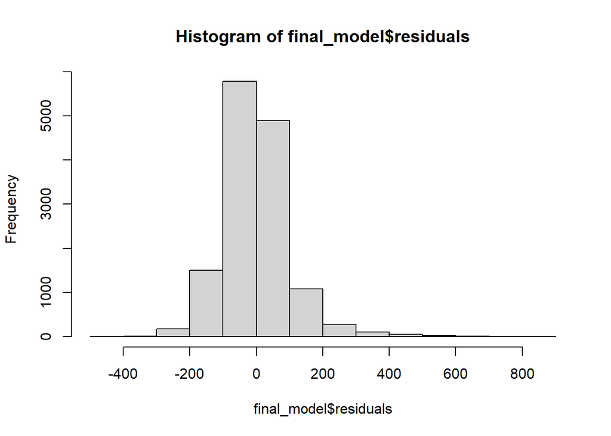

```r
final_model <- lm(sqrt(SALE_PRC) ~ .,data = data[y])
hist(final_model$residuals)
```

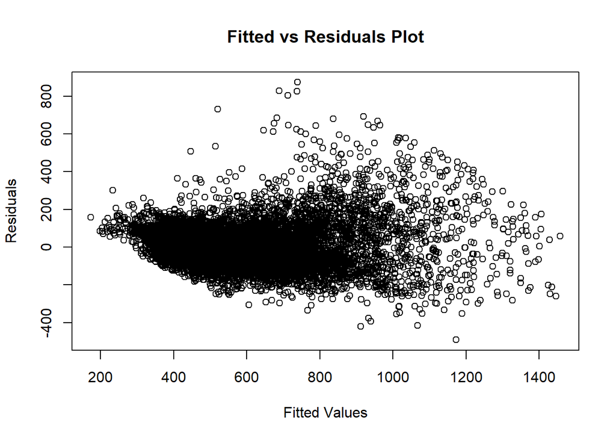

```r
# Create the plot
plot(final_model$fitted.values, final_model$residuals, xlab = "Fitted Values", ylab = "Residuals", main = "Fitted vs Residuals Plot")
```

#### Heterosdedastyczność - Test Breuscha-Pagana

Bazując na bardzo małym p-value, istnieją podstawy do odrzucenia hipotezy zerowej o braku heteroskedastyczności. Oznacza to, że wariancja reszt w istocie jest różna a model niedopasowany.

```r
bptest(final_model)
```

```
##
##  studentized Breusch-Pagan test
##
## data:  final_model
## BP = 1559, df = 5, p-value < 2.2e-16
```

#### Heterosdedastyczność - Test Durbina-Watsona

Bazując na bardzo małym p-value dla tego testu, istnieją także podstawy do odrzucenia hipotezy zerowej o braku autokorelacji. Oznacza to, że zmienne są między sobą istotnie skorelowane, co także oznacza słabe dopasowanie modelu.

```r
dwtest(final_model)
```

```
##
##  Durbin-Watson test
##
## data:  final_model
## DW = 0.86558, p-value < 2.2e-16
## alternative hypothesis: true autocorrelation is greater than 0
```

### Podsumowanie

Ostatecznie model po przeprowadzeniu diagnostyki zostaje odrzucony z powodu braku spełnienia podstawowych założeń, między innymi o normalności reszt i nieheteroskedastyczności.